# Hostility on Twitter in the Aftermath of Terror Attacks

Institute of Sociology, University of Bern

Dr. Christian S. Czymara

22 Mar 2024

## Relevance

- Attacks shape inter-group relations in increasingly diverse societies
  - Out-group hostility (Godefroidt 2022)
  - Mental health among majority (Pirard 2020) & Muslims (Frey 2021)
  - More discrimination felt by Muslims (Giani & Merlino 2020)
- Research question: *Does ethno-religious hostility on social media increase after Islamist terror attacks?*
- Online hate speech correlates with
  - Far-right votes (Giavazzi 2023)
  - Anti-refugee violence (Müller & Schwarz 2021)

## Contribution

- Studying effects of terrorist attacks on ethno-religious hostility in migration debates on Twitter
- Over 4.5 million Tweets posted by about 1.2 million accounts in five countries after 10 major attacks
- Time-stamped data capturing naturally occurring behavior in a “digital socioscope” (Pfeffer et al. 2023)
- Analyzing attitudes at the moment a person decides to express them

# Theory

## Terrorism as group threat

*“It is the events seemingly loaded with great collective significance that are the focal points of the public discussion. […] When this public discussion takes the form of a denunciation of the subordinate racial group, signifying that it is unfit and a threat, the discussion becomes particularly potent in shaping the sense of social position”* Blumer (1958): 6

## Terrorism as group threat

- Terrorist attacks pose a threat to individual and collective safety
- And strengthen intolerance and prejudice
- H1: Ethno-religious hostility increases after terror attacks
- However, effect tends to be short-lived (Hopkins 2010; Legewie 2013)
- H2: The effect of H1 levels off over time

## General and specific components of threat

- Attacks can shape attitudes toward groups that are often associated with the attacks
- H3a: Islamist attacks have the strongest effect on Tweets about Muslims
- However, terrorism sometimes blamed on immigration in general (Helbling & Meierrieks 2020)
- H3b: There is a spillover effect onto Tweets about migration in general

## Mechanism

- Attitudinal change vs. compositional change
- Group threat theory implies users update their views
- H4: Within users’ hostility increases after terror attacks

# Data

## Overview of attacks

| City | Date | Attack | Deaths | Injuries | Abbreviation |
| --- | --- | --- | --- | --- | --- |
| Paris (FR) | 7–9 January 2015 | Charlie Hebdo + kosher supermarket shootings | 17 | 19 | FR15_CH |
| Paris (FR) | 13 November 2015 | Bataclan shootings and other attacks | 137 | 413 | FR15_BATA |
| Brussels (BE) | 22 March 2016 | Airport and metro station bombings | 32 | 340 | BE16 |
| Nice (FR) | 14 July 2016 | Bastille Day truck attack | 87 | 270 | FR16 |
| Berlin (DE) | 19 December 2016 | Christmas market truck attack | 13 | 48 | DE16 |
| London (UK) | 22 March 2017 | Westminster Bridge attack | 5 | 48 | UK17_west |
| Manchester (UK) | 22 May 2017 | Manchester Arena bombing | 22 | 239 | UK17_man |
| London (UK) | 3 June 2017 | London Bridge attack | 8 | 48 | UK17_lon |
| Barcelona (ES) | 17 August 2017 | Van attacks | 15 | 104 | ES17 |
| Strasbourg (FR) | 11 December 2018 | Christmas market attack | 5 | 11 | FR18 |

Source: https://www.start.umd.edu/gtd/search/

## Search string

- Goal: Identify Tweets that deal with migration related topics
- Should include Muslims (much debated migrant group)
- But no direct search for insults or derogatory terms, nor attack specific hashtags
- Language-specific search string, English version:

```
 [1] "migration"   "immigration" "migrant"     "immigrant"   "foreigner"
 [6] "migrants"    "immigrants"  "foreigners"  "refugee"     "refugees"
[11] "asylum"      "islam"       "muslim"      "muslims"
```

# Descriptive overview

## Distribution of Tweets before and after attacks

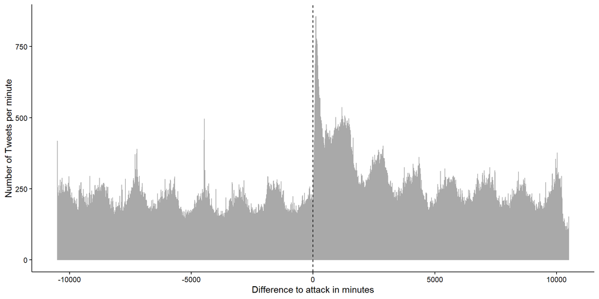

## Measuring ethno-religious hostility

- Relying on of Google Jigsaw’s Conversation AI’s [Perspective](https://perspectiveapi.com/)
- *“Perspective is trained to recognize a variety of attributes (e.g. whether a comment is toxic, threatening, insulting, off-topic, etc.) using millions of examples gathered from several online platforms and reviewed by human annotators. Probability scores represent a probability, with a value between 0 and 1. A higher score indicates a greater likelihood that a reader would perceive the comment as containing the given attribute.”* ([Google](https://support.perspectiveapi.com/s/about-the-api-faqs?language=en_US))

## Measuring ethno-religious hostility

- Perspective’s IDENTITY_ATTACK attribute, which measures “Negative or hateful comments targeting someone because of their identity.” ([Google](https://support.perspectiveapi.com/s/about-the-api-attributes-and-languages?language=en_US))
- In this context, I assume identity proxies ethnicity, race, or religion
- Based on convolutional neural networks (Dixon 2018), details of the algorithm are proprietary

## Validation

- Annotated a random sample of Tweets, stratified by hostility level and case
- Almost perfectly selected hostile Tweets only: Precision of 98 percent ($\frac{true positive}{true positives + false positives}$)
- High ability to detect hostility: Recall of 82 percent  
  ($\frac{true positive}{true positives + false negatives}$)

# Method

## Statistical model

- Dependent variable: Probability to be ethno-religiously hostile (ranging from 0 to 100)
- Predictor: Posted either in the week before or after the attack (binary variable)
- Running variable that counts the time before and after the attack (in *minutes*) to measure trends
- Interrupted time series: $p(hostility)=\beta_0+\beta_1attack+\beta_2time\_since\_attack +$ $\beta_3attack*time\_since\_attack+\beta_4case+\epsilon$
- Cluster-robust standard errors at the user level

# Results

## Results (H1 & H2)

|  | IDENTITY ATTACK 100 |
| --- | --- |
| Predictors | Estimates |
| attack diff num | 0.000001 (-0.000006 – 0.000009) |
| attack befaft01 | 9.876590 *** (9.812098 – 9.941083) |
| attack diff num × attack befaft01 | -0.001002 *** (-0.001013 – -0.000992) |
| Observations | 4596300 |
| AIC | 39791994.051 |
| * p<0.05 ** p<0.01 *** p<0.001 |  |

## Putting effect size into perspective

- Hourly trend after attack: -0.06 percentage points
- Daily trend after attack: -1.443 pp
- The hostility level has returned to its prior level after 6.845 days

## Variation across attacks

- Allow both the attack effect and the trends to vary across cases
- Three-way interaction model: $p(hostility)=\beta_0+\beta_1attack+\beta_2time\_since\_attack+\beta_3case +$ $[twoway\_interactions]+\beta_4attack*time\_since\_attack*case+\epsilon$

## Variation across attacks

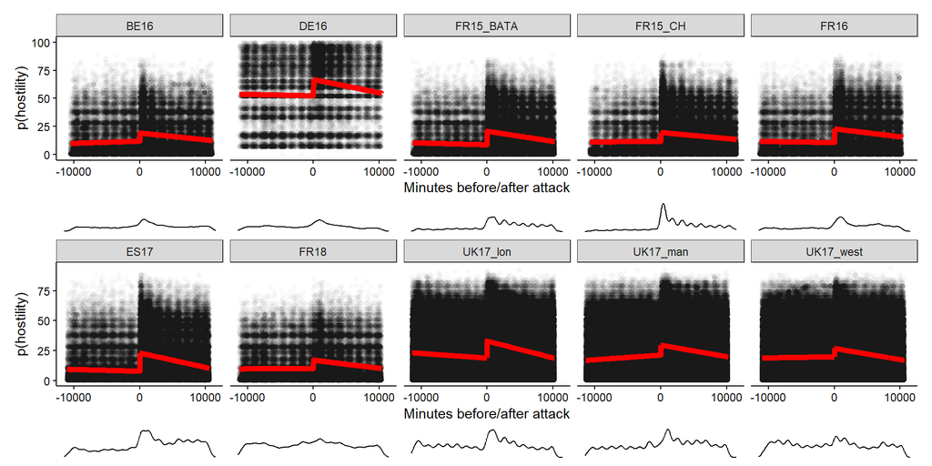

## Non-linear trends

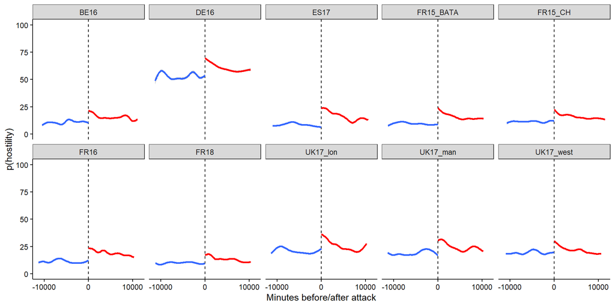

## Without Tweets about Muslims or Islam (H3a & H3b)

- 909841 Tweets do *not* mention Muslims or Islam at all
- Immediate attack effect: 8.156 pp ($p<$ 0.001) (compared to effect in pooled model: 9.877 pp)
- Pre-attack trend: -0.001 pp per hour ($p=$ 0.19)
- Post-attack trend: -0.047 pp per hour ($p<$ 0.001)

## Intra-individual change (H4)

- Fixed effects model
- Analyzing a subset of accounts that Tweeted at least once before *and* after an attack
- Somewhat different sample

## Intra-individual change (H4)

- Immediate attack effect: 3.594 pp ($p<$ 0.001) (compared to effect in pooled model: 9.877 pp)
- Pre-attack trend: 0 pp per hour ($p=$ 0.088)
- Post-attack trend: -0.019 pp per hour ($p<$ 0.001)

## Robustness checks

- Binary outcomes (75% & 90% threshold) and logistic regression
- Removing top 1% of highly active accounts (bots?)
- Only before period, cut in half: no effect
- Random treatment timing: no effect

# Summing up

## Conclusion

- Islamist terrorism fuels online hate across cases and countries
- Higher hostility levels after attacks
- Due to individuals becoming more hostile
- … and due to new people entering the debates
- Limitation: deletion of hate speech (results overly conservative)

## Open Science

- Paper forthcoming at *Journal of Computational Social Science* (open access)
- Preprint available at: [OSF](https://osf.io/preprints/socarxiv/yjmp6)
- Code available at: [OSF](https://osf.io/zdt5b/) (soon)

## Appendix

- Ethno-religious hostility: Aggressive, antagonistic, or negative interactions and rhetoric aimed at ethno-religious minorities or migrants, often characterized by prejudice, xenophobia, and discrimination